# Stat 579 - Homework #7

Urminder Singh

10/21/2018

## Chick Weights

For this assignment we will use the data set `ChickWeight`. You need to load the data in R using `data(ChickWeight)`. The `ChickWeight` data frame has 578 rows and 4 columns from an experiment on the effect of diet on early growth of chicks. Use `?ChickWeight` to get more information on every one of the variables.

1. Download the RMarkdown file with these homework instructions to use as a template for your work. Make sure to replace “Your Name” in the YAML with your name.
2. Each chick should have twelve weight measurements. Use the `dplyr` package to identify how many chicks have a complete set of weight measurements and how many measurements there are in the incomplete cases. Extract a subset of the data for all chicks with complete information and name the data set `complete`. (Hint: you might want to use `mutate` to introduce a helper variable consisting of the number of observations)

```r
library(dplyr)
```

```r
library(ggplot2)
ChickWeight %>%  count(Chick) %>% filter(n <12)
```

```
## # A tibble: 5 x 2
##   Chick     n
##   <ord> <int>
## 1 18        2
## 2 16        7
## 3 15        8
## 4 8        11
## 5 44       10
```

```r
complete<-ChickWeight %>% group_by(Chick) %>% mutate(count = n())  %>% filter(count==12)
```

5 chicks had incomplete measurements. These were 8, 15, 16, 18 and 44

3. In the `complete` data set introduce a new variable that measures the current weight difference compared to day 0. Name this variable `weightgain`.

```r
complete<-complete  %>%  group_by(Chick) %>% mutate(weightgain = weight-first(weight))
```

4. Using the `ggplot2` package create side-by-side boxplots of `weightgain` by `Diet` for day 21. Describe the relationship in 2-3 sentences. Change the order of the categories in the `Diet` variable such that the boxplots are ordered by median `weightgain`.

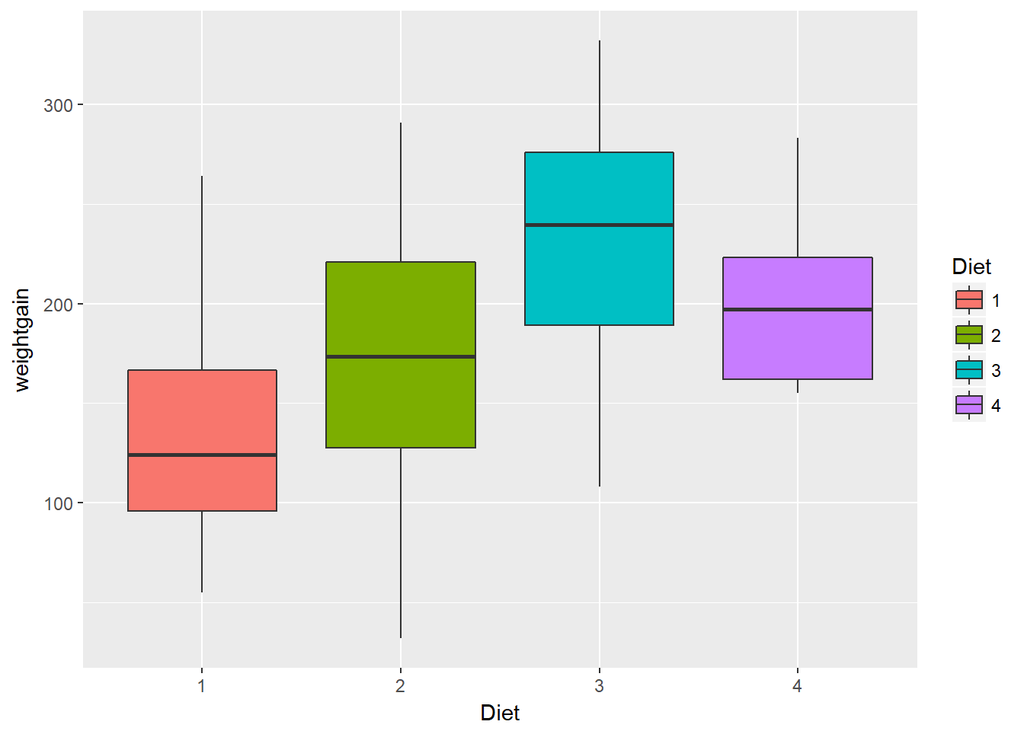

```r
ggplot(data=complete %>% filter(Time==21),aes(x=Diet)) + geom_boxplot(aes(y=weightgain,fill=Diet))
```

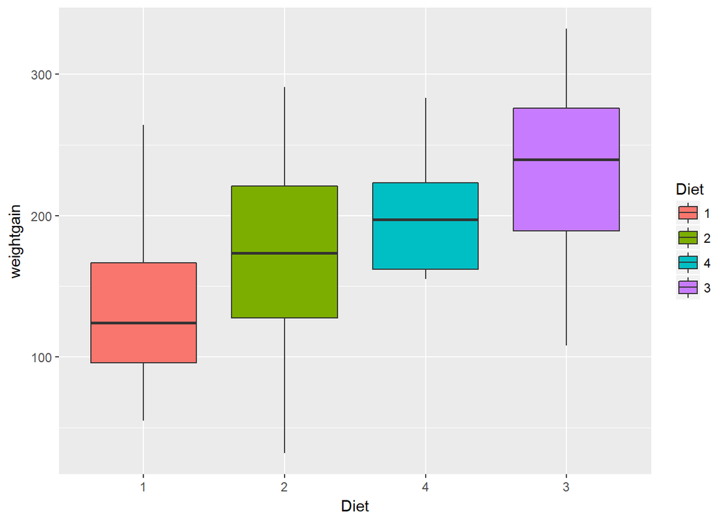

```r
#sort increasing
ggplot(data=complete %>% filter(Time==21),aes(x=reorder(Diet,weightgain,FUN = median))) + geom_boxplot(aes(y=weightgain,fill=reorder(Diet,weightgain,FUN = median)))+
  xlab("Diet") + scale_fill_discrete(guide = guide_legend(title = "Diet"))
```

From the figure we see that for each diet, the median and spread of weight gain on 21st day is different. Diet 3 has highest median weightgain and diet 1 has lowest median. Diet 2 has highest spread and diet 4 has lowest spread.

5. Draw a plot of weight by time. Facet by `Diet`. Use a point layer and also draw one line for each `Chick` (use `geom_line` and specify `group = Chick`). Color by `Diet`.  
   Comment on the plot in 2-3 sentences.

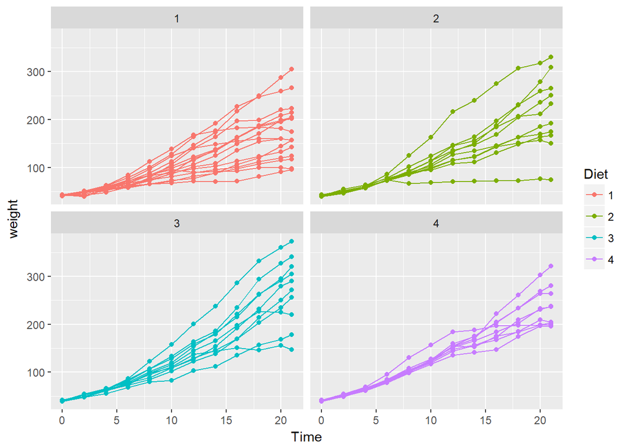

```r
ggplot(data=complete ,aes(x=Time,y=weight))+ geom_point(aes(colour=Diet)) + facet_wrap(~Diet)+ geom_line(aes(x=Time,y=weight, group = Chick, colour=Diet))
```

6. Comment on the two resulting plots below. Which plot best describes the effect of the diets on the chicks?
1. Select the `Chick` with the maximum weight at `Time` 21 for each of the diets. Redraw the previous plot with only these 4 chicks (and don’t facet).
2. Compute average daily weights under each Diet and redraw the plot (using the same structure and aesthetics as before).

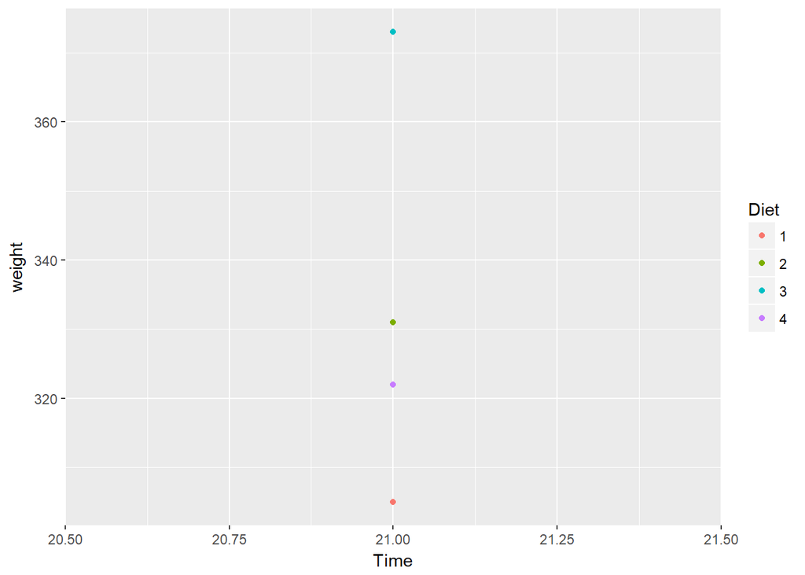

```r
ggplot(data=complete%>%group_by(Diet)%>%filter(Time==21)%>%filter(weight==max(weight)) ,aes(x=Time,y=weight))+ geom_point(aes(colour=Diet))
```

The above plot shows the weight of 4 chicks which were heaviest in each diet group on day 21. This plot only shows the maximum of the weight variable for each diet group. This plot isn’t the best to copare overall effect of diets on weight of chicks as it only compares the extreme values and is only plotted for the last day. It doesn’t show any variation over time.

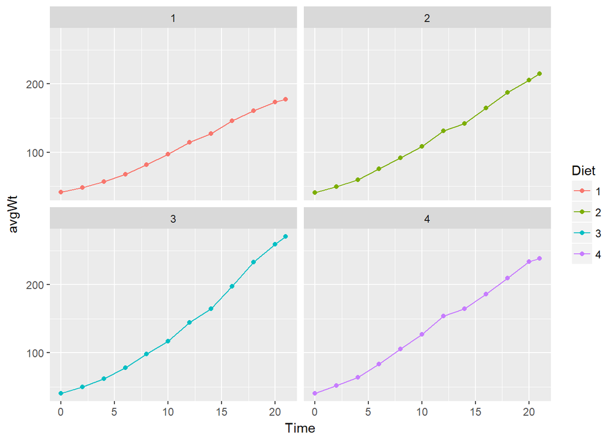

```r
ggplot(data=complete %>% group_by(Time,Diet) %>% mutate(avgWt=ave(weight)) ,aes(x=Time,y=avgWt))+ geom_point(aes(colour=Diet)) + facet_wrap(~Diet)+ geom_line(aes(x=Time,y=avgWt, colour=Diet))
```

The second plot shows average weight in each diet group over time. The mean is computed for all the chicks in a diet group. This plot is better to compare the effect of diets on the weights. We can see how the mean weight changes over time for each diet group.